# Positive selection scan on Capybara genome

Santiago Herrera-Alvarez

September 2, 2020

```r
library(ggplot2)
library(biomaRt)
library(ggrepel)
library(MCMCtreeR) #remotes::install_github("PuttickMacroevolution/MCMCtreeR")
library(ggtree) #BiocManager::install("ggtree")
library(tidyverse)
library(qvalue)
```

## Data: LRTs and PDIs

Amino acid sites within a protein may experience different selective pressures and have different underlying $d_N/d_S$ ratios (Yang et al., 2000; Smith et al. 2015). We fitted branch-site models to identify positive selection in a set of 4,452 SCOs obtained using the OrthoVenn software (Wang et al., 2015) on capybara versus four closely related rodents with published whole genome sequences: naked mole rat, degu, chinchilla and guinea pig.

- **LRTs**: Likelihood-ratio tests (LRT) between two models of codon evolution were used as a measure of model fit: 1) a branch-site model (model A) which attempts to detect positive selection acting on a few sites on specified lineages or 'foreground branches' ($d_N/d_S$>1), versus the null model (A null) in which codons can only evolve neutrally ($d_N/d_S$ =1) or under purifying selection (0< $d_N/d_S$ <1; Zhang et al., 2005); 2) an adaptive branch-site random effects model (aBSREL; Smith et al. 2015) which determines the proportion of sites with $d_N/d_S$>1 on the foreground branch relative to a null model (0< $d_N/d_S$ =<1). **NOTE: results of LRTs for each of the 4,452 SCOs are available in the table `LR_Pval_codeml_absrel.csv`. The p-values correspond to each LRT**
- **PDI**: ((Capybara, guinea pig), degu) protein trios where used to estimate the difference of the raw p-distance in protein sequence between capybara and (pdCD), and the raw p-distance between guinea pig and degu (pdGD). These two distances were used to calculate the 'protein distance index' or PDI for each (PDIi = pdCDi - pdGDi) which takes a value of zero if the two p-distances are equal, meaning that the capybara and guinea pig lineages have evolved at equal rates since their divergence from their most recent common ancestor (MRCA). A positive value is indicative of accelerated protein evolution in the capybara lineage. **NOTE: results of PDI for each of the 4,452 SCOs are available in the table `genetic_dists.csv`.**

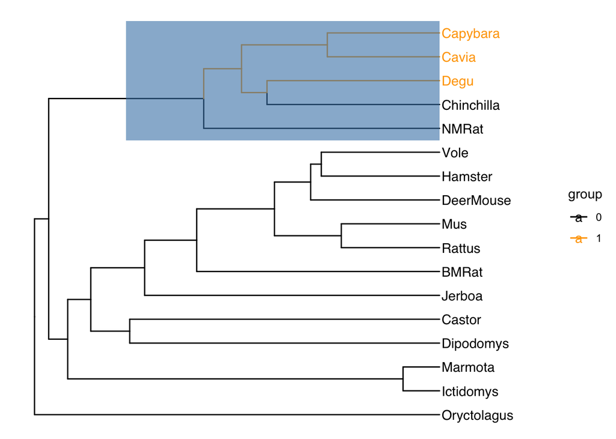

**ORANGE:** Scope of the PDI analysis  
**BLUE:** Scope of the positive selection analysis using branch-site models

### Exploratory analysis

**NOTE: The file `genetic_dists.csv` contains the following information: SCO-cluster name, Guinea pig ensembl prot id, Tamura-Nei distance for DNA seqs, and protein raw-p distance**

Tamura-Nei distances of DNA sequences and raw-p distances were computed on ((Capybara, guinea pig), degu) orthologs.

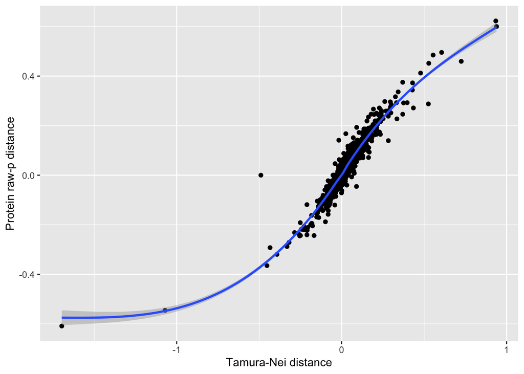

## model A (codeml) and aBSREL (HyPhy) results are strongly correlated

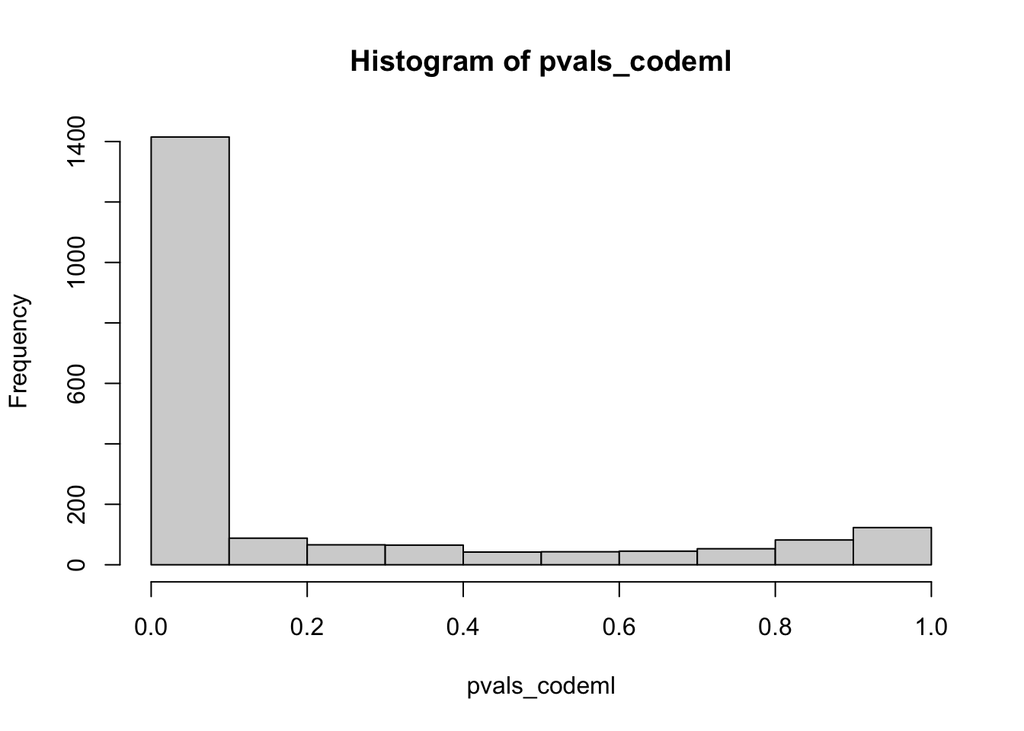

```
# [1] "Number of genes under positive selection under codeml model A with an FDR of 0.01:  1229"
# [1] "Number of genes under positive selection under codeml model A after Bonferroni correction < 0.01:  920"
```

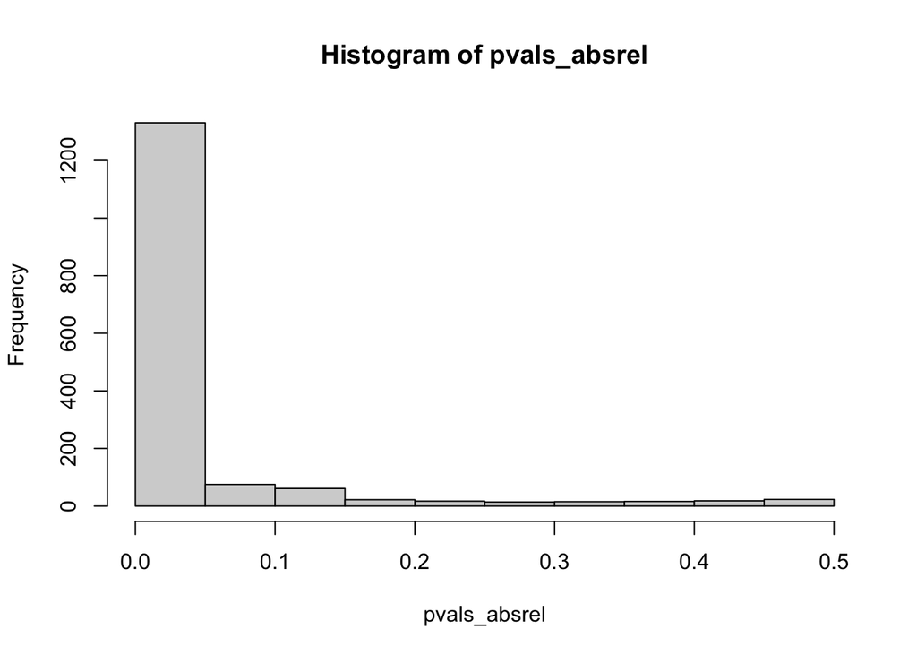

```
# [1] "Cannot compute qvalues for truncated p-value distributions"
# [1] "Number of genes under positive selection under aBSREL after Bonferroni correction < 0.01:  861"
```

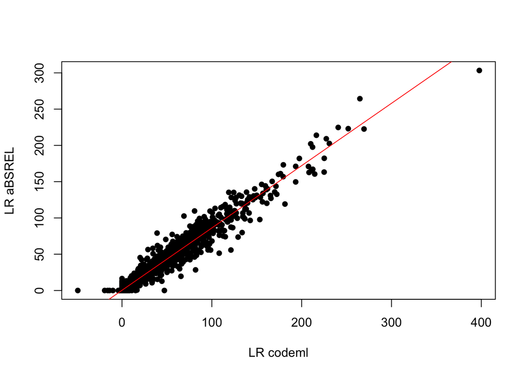

```
#
#   Pearson's product-moment correlation
#
# data:  t2$LR_codeml and t2$LR_aBSREL
# t = 360.46, df = 4439, p-value < 2.2e-16
# alternative hypothesis: true correlation is not equal to 0
# 95 percent confidence interval:
#  0.9823429 0.9842879
# sample estimates:
#       cor
# 0.9833435
#
#
#   Wilcoxon rank sum test with continuity correction
#
# data:  t2$LR_codeml and t2$LR_aBSREL
# W = 10429750, p-value = 1.495e-07
# alternative hypothesis: true location shift is not equal to 0
```

## Plot of the genes on a two-dimension graph with coordinates x=LR, y=PDI

We considered genes in the top 5% of the distribution in both dimensions (i.e., the LRTs of branch-site models and the PDI statistic) as positively selected in the capybara lineage. We used a standardized PDI statistic to account for differences in the rates of evolution between proteins.

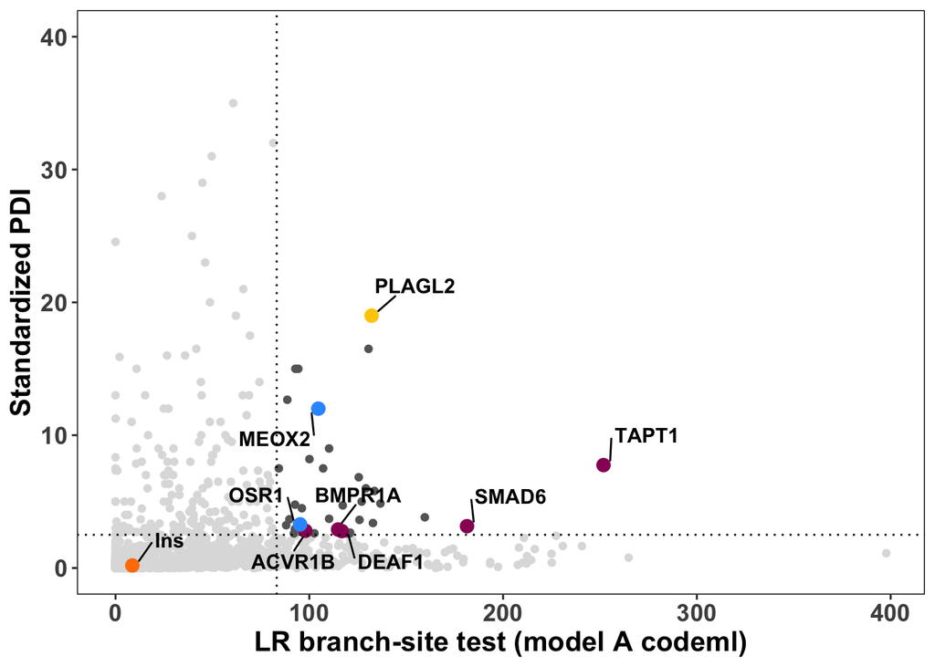

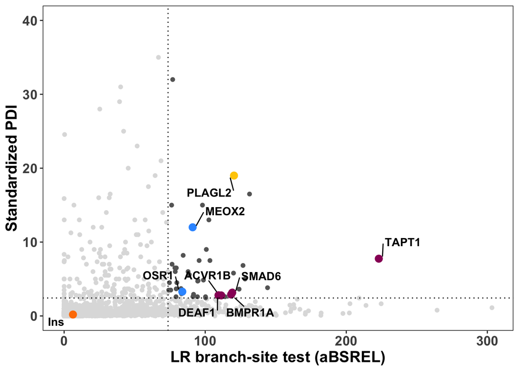

Interestingly, Insulin is not positevely selected in the capybara, although it has been shown to have signatures of positive selection in caviomorph rodents (Opazo et al., 2005). However, insulin transcription and secretion mediated by PDX1 (see pairwise comparisons) may be part of the underlying mechanism regulating body size evolution in the capybara.

## Fisher's exact test (GO enrichment) of genes under positive selection: GOSlim GOA descriptions

|  | GO_term | fisherPvalues_out | fisherPvalues_out_Bonferroni |
| --- | --- | --- | --- |
| 7 | cellular nitrogen compound metabolic process | 1.424294e-11 | 1.096707e-09 |
| 8 | biosynthetic process | 5.877243e-07 | 4.525477e-05 |
| 13 | ion binding | 1.710240e-07 | 1.316885e-05 |
| 14 | kinase activity | 4.749429e-40 | 3.657061e-38 |
| 15 | cellular protein modification process | 3.560972e-06 | 2.741948e-04 |
| 18 | anatomical structure development | 4.104188e-10 | 3.160224e-08 |
| 19 | embryo development | 6.459868e-76 | 4.974099e-74 |
| 20 | growth | 9.083779e-21 | 6.994510e-19 |
| 21 | cell differentiation | 2.296696e-06 | 1.768456e-04 |
| 22 | immune system process | 2.075843e-17 | 1.598399e-15 |

[output cut: 18 more lines]

## Fisher's exact test (GO enrichment) of genes under positive selection: GO ids

TreeMap from REVIGO for GO biological processes terms represented by genes evolving under positive selection in the capybara. Rectangle size reflects semantic uniqueness of GO term, which measures the degree to which the term is an outlier when compared semantically to the list of terms present in the mouse.

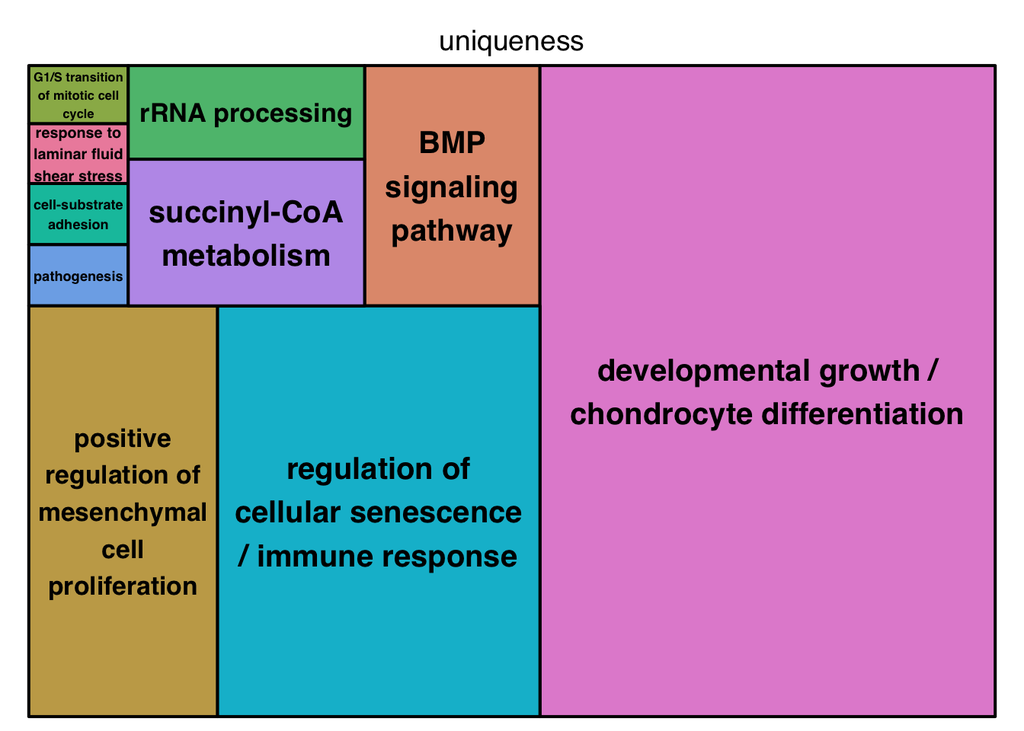

```
# Note: tmPlot deprecated as of version 2.0. Please use treemap instead.
```